# Visualització de dades - Pràctica 2

### Alumne: Maria Font Sánchez

### Part I: Prepració de les dades

### Conjunt de dades

Els projectes i resultats de recerca i innovació, finançats per la Unió Europea durant els anys 2014 i 2020 sota el programa Horizon 2020, són accesibles per a qualsevol ciutadà des del [portal de dades obertes de la Comissió Europea](https://data.europa.eu/en).  
En aquest cas, el dataset utilitzat s'anomena [**CORDIS - EU research projects under Horizon 2020 (2014-2020)**](https://data.europa.eu/data/datasets/cordish2020projects?locale=en).  
Per aquesta visualització, s'han utilitzat les dades relacionades amb els projectes H2020, que inclou la descripció dels projectes, les diferentes organitzacions que han estat involucrades, i la categorització per a cada projecte a partir de la taxonomia d'[EuroSciVoc](https://op.europa.eu/es/web/eu-vocabularies/euroscivoc) (aquesta taxonomia categoritza tots els camps de la ciència en múltiples idiomes).

### Preguntes i elecció de dades

1. Per a cada país, en funció del coordinador del projecte, quines són les categories dels projectes amb més rellevància (segons EuroSciVoc)?
2. En quines categories d’EuroSciVoc s’hi ha invertit més?
3. Quines són les organitzacions involucrades en més projectes? De quin tipus són?

Per tal de respondre a aquesta preguntes, s'ha realitzat una fusió de tres de les distribucions que es troben en el dataset indicat anteriorment:

- **Projects**: s'han agafat 35381 projectes que hi ha actualment en el dataset.
- **Organisations**: cada projecte té entre 1 i múltiples organitzacions, tot i així, s'han filtrar les organitzacions que són les coordinadores dels projectes ja que són les que tenen més pes. Per tant, s'ha fusionat fent una relació d'un projecte amb una organització.
- **EuroSciVoc**: cada projecte té entre 0 i múltiples categories. Per tal de facilitar la fusió, les categories d'un mateix projecte s'han ajuntat en una única llista de paraules (separades per coma). Per tant, s'ha pogut fer la fusió d'un projecte amb un llistat de categories.

Un cop es té el dataset que s'utilitzarà per a la visualització, es mostra el detall dels atributs:

[output not shown]

### Exploració de les dades

Per tal de poder realitzar l'exploració de les dades, primer realitzo la lectura del fitxer Excel i mostro la informació de les columnes i el tipus de columnes:

```python
import pandas as pd

pd.options.display.float_format = '{:.5f}'.format
df = pd.read_excel('Horizon 2020/project_clean.xlsx', decimal=',')
```

```python
df.info()
```

```
<class 'pandas.core.frame.DataFrame'>
RangeIndex: 35381 entries, 0 to 35380
Data columns (total 21 columns):
 #   Column             Non-Null Count  Dtype
---  ------             --------------  -----
 0   id                 35381 non-null  int64
 1   status             35381 non-null  object
 2   title              35381 non-null  object
 3   startDate          35370 non-null  object
 4   endDate            35370 non-null  object
 5   totalCost          35381 non-null  float64
 6   ecMaxContribution  35381 non-null  float64
 7   objective          35381 non-null  object
 8   vatNumber          34079 non-null  object
 9   name               35381 non-null  object
 10  SME                35354 non-null  object
 11  activityType       35381 non-null  object
 12  street             35353 non-null  object
 13  postCode           35292 non-null  object
 14  city               35354 non-null  object
 15  country            35381 non-null  object
 16  geolocation        35370 non-null  object
 17  ecContribution     35374 non-null  float64
 18  netEcContribution  35379 non-null  float64
 19  totalCostOrg       35374 non-null  float64
 20  euroscivoc         34126 non-null  object
dtypes: float64(5), int64(1), object(15)
memory usage: 5.7+ MB
```

```python
total = df.isnull().sum().sort_values(ascending=False)
percent = (df.isnull().sum()/df.isnull().count()).sort_values(ascending=False)
missing_data = pd.concat([total, percent], axis=1, keys=['Total', 'Percent'])
missing_data[missing_data['Total'] > 0]
```

|  | Total | Percent |
| --- | --- | --- |
| vatNumber | 1302 | 0.03680 |
| euroscivoc | 1255 | 0.03547 |
| postCode | 89 | 0.00252 |
| street | 28 | 0.00079 |
| city | 27 | 0.00076 |
| SME | 27 | 0.00076 |
| endDate | 11 | 0.00031 |
| startDate | 11 | 0.00031 |
| geolocation | 11 | 0.00031 |
| ecContribution | 7 | 0.00020 |
| totalCostOrg | 7 | 0.00020 |
| netEcContribution | 2 | 0.00006 |

La càrrega del XLSX s'ha carregat correctament, a més, es pot observar que les variables quantitatives s'han tranformat al tipus Float. També, hi ha registres amb valors no disponibles. Com per exemple, vatNumber o la ciutat, ja que és una dada que formarà part de la visualització de forma informativa.

La categoria d'EuroSciVoc no emplenada, són projectes que no són d'àmbit científic, sinó d'organització per a crear xarxes entre organitzacions científiques.

Executo un box plot per a les dades quantitatives (a excepció de l'identificador), per comprovar si hi ha valors atípics:

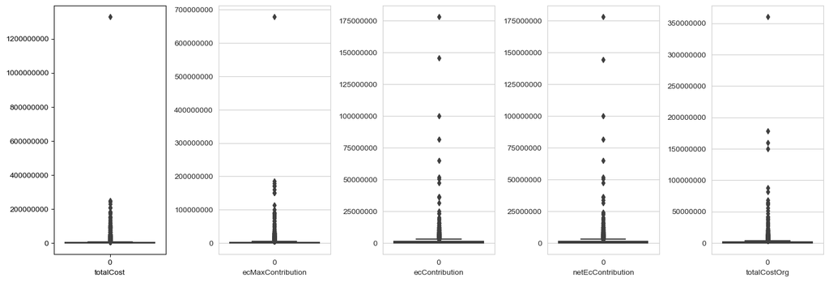

```python
import matplotlib.pyplot as plt
import seaborn as sns

colnames = ['totalCost', 'ecMaxContribution', 'ecContribution', 'netEcContribution', 'totalCostOrg']

plt.figure(figsize=(15, 100))
for i in range(0, 5):
    plt.subplot(20, 5,i+1)
    sns.set_style('whitegrid')
    sns.boxplot(data=df[colnames[i]], orient='v')
    plt.ticklabel_format(style='plain', axis='y')
    plt.xlabel(colnames[i])
    plt.tight_layout()
```

```python
# S'avaluen els outliers:
df[df['totalCost']>1000000000]
```

|  | id | status | title | startDate | endDate | totalCost | ecMaxContribution | objective | vatNumber | name | ... | activityType | street | postCode | city | country | geolocation | ecContribution | netEcContribution | totalCostOrg | euroscivoc |
| --- | --- | --- | --- | --- | --- | --- | --- | --- | --- | --- | --- | --- | --- | --- | --- | --- | --- | --- | --- | --- | --- |
| 31842 | 633053 | SIGNED | Implementation of activities described in the ... | 2014-01-01 | 2022-12-31 | 1329689211.50000 | 678800000.00000 | A Roadmap to the realization of fusion energy ... | DE129517720 | MAX-PLANCK-GESELLSCHAFT ZUR FORDERUNG DER WISS... | ... | REC | HOFGARTENSTRASSE 8 | 80539 | MUNCHEN | DE | 48.1411687,11.5822929 | 145585005.96000 | 144553755.96000 | 360207403.92000 | nuclear fusion |

1 rows × 21 columns

```python
df[df['totalCostOrg']>100000000]
```

|  | id | status | title | startDate | endDate | totalCost | ecMaxContribution | objective | vatNumber | name | ... | activityType | street | postCode | city | country | geolocation | ecContribution | netEcContribution | totalCostOrg | euroscivoc |
| --- | --- | --- | --- | --- | --- | --- | --- | --- | --- | --- | --- | --- | --- | --- | --- | --- | --- | --- | --- | --- | --- |
| 14944 | 101018100 | SIGNED | PROPOSAL FOR FUNDING RESEARCH DEVELOPMENT AND ... | 2020-07-24 | 2026-01-23 | 150000000.00000 | 100000000.00000 | Funding of research and innovation programmes ... | NaN | COALITION FOR EPIDEMIC PREPAREDNESS INNOVATION | ... | REC | MARCUS THRANSES GATE 2 | 473 | OSLO | NO | 60.0518829,10.6799603 | 100000000.00000 | 100000000.00000 | 150000000.00000 | virology,pandemics,coronaviruses,vaccines |
| 15242 | 681463 | CLOSED | COST at a turning point: A unique framework fo... | 2015-05-01 | 2019-04-30 | 178169171.00000 | 178169171.00000 | COST is an intergovernmental framework for coo... | NaN | COST ASSOCIATION | ... | OTH | MANHATTAN CENTRE AVENUE DE BOULEVARD 21/2 | 1210 | BRUXELLES | BE | 50.8287051,4.3621168 | 178169171.00000 | 178169171.00000 | 178169171.00000 | governance,history,civil society,law |
| 31842 | 633053 | SIGNED | Implementation of activities described in the ... | 2014-01-01 | 2022-12-31 | 1329689211.50000 | 678800000.00000 | A Roadmap to the realization of fusion energy ... | DE129517720 | MAX-PLANCK-GESELLSCHAFT ZUR FORDERUNG DER WISS... | ... | REC | HOFGARTENSTRASSE 8 | 80539 | MUNCHEN | DE | 48.1411687,11.5822929 | 145585005.96000 | 144553755.96000 | 360207403.92000 | nuclear fusion |
| 32356 | 737417 | SIGNED | 300mm Pilot Line for Smart Power and Power Dis... | 2017-11-01 | 2023-04-30 | 180318047.50000 | 28046206.50000 | R3-POWERUP will push through the new generatio... | IT00951900968 | STMICROELECTRONICS SRL | ... | PRC | VIA C.OLIVETTI 2 | 20864 | AGRATE BRIANZA | IT | 45.5762329,9.3524409 | 23244092.00000 | 23244092.00000 | 160000000.00000 | nanotechnology,productivity |

4 rows × 21 columns

Després de verificar en la web de CORDIS que els costos d'aquests projectes són els reals, i es confirma que aquests no són outliers.  
Es transforma les dades del tipus data "startDate" i "endDate" al tipus datetime:

```python
df["startDate_date"] = pd.to_datetime(df["startDate"], format='%Y-%m-%d')
df["endDate_date"] = pd.to_datetime(df["endDate"], format='%Y-%m-%d')
```

Finalment, es passa les dades categòriques al tipus "category" i es fa un gràfic de barres de cadascun per veure les seves característiques. Les dades categòriques són l'estat ("status"), tipus d'activitat ("activityType") i país ("country"). Pel que fa a les dades categòriques d'euroSciVoc, primer caldrà fer un preprocessament.

```python
df["status_cat"] = df["status"].astype("category")
df["activityType_cat"] = df["activityType"].astype("category")
df["country_cat"] = df["country"].astype("category")
```

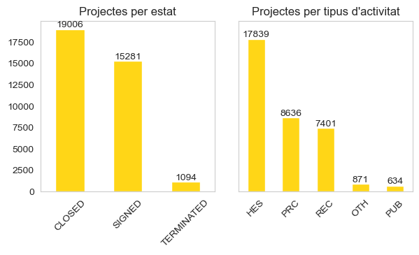

```python
fig, axes = plt.subplots(nrows=1, ncols=2, figsize=(6, 3), sharey=True)
fig.tight_layout()

ax1 = pd.value_counts(df["status_cat"]).plot.bar(ax=axes[0], rot=45, color="#FFD617", grid=False)
ax1.bar_label(ax1.containers[0])
ax1.set_title("Projectes per estat")

ax2 = pd.value_counts(df["activityType_cat"]).plot.bar(ax=axes[1], rot=45, color="#FFD617", grid=False)
ax2.bar_label(ax2.containers[0])
ax2.set_title("Projectes per tipus d'activitat")
```

Per tal de poder realitzar la visualització, primer es passa de la ISO 3166-1 alpha-2 a alpha-3, és a dir, de 2 a 3 dígits.

```python
from pycountry_convert import *

df['country_alpha_3'] = df.country_cat.apply(lambda x:
                                             country_name_to_country_alpha3(country_alpha2_to_country_name("GR")) if x=="EL"
                                             else country_name_to_country_alpha3(country_alpha2_to_country_name("GB")) if x=="UK"
                                             else country_name_to_country_alpha3(country_alpha2_to_country_name(x)))
```

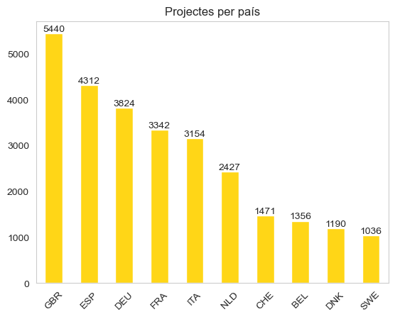

```python
ax3 = pd.value_counts(df["country_alpha_3"]).nlargest(10).plot.bar(rot=45, color="#FFD617", grid=False)
ax3.bar_label(ax3.containers[0])
ax3.set_title("Projectes per país")
```

En els diagrames de barres de les dades categoritzades es pot observar una clara tendència que els projectes d'organitzacions amb activitats universitàries (HES), seguides d'empreses del sector privat (PRC) i enfocades en el món de la recerca (REC). També, la majoria dels projectes ja estan tancats, però encara hi ha una mica menys de la meitat en procés. I finalment, l'últim gràfic mostra el top 10 paísos amb organitzacions coordinadores dels projectes.

```python
# Transformo EuroSciVoc a un llistat de categories (actualment és un string separats per coma),
# eliminant abans dels valors NaN a valors buits.
import numpy as np

df_euroscivoc = df["euroscivoc"].replace(np.nan, None).str.split(",", expand=True).astype('category')

for column in df_euroscivoc:
    columnCat = df_euroscivoc[column]
    df["euroscivoc_cat_"+str(column)] = columnCat.values
```

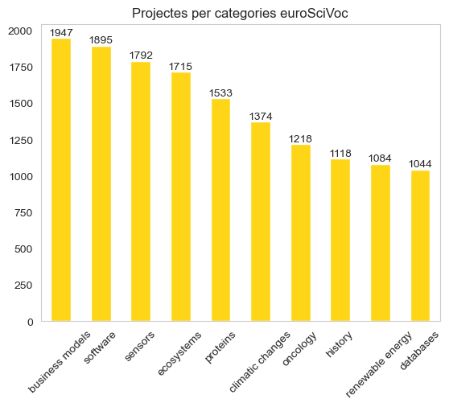

```python
ax5 = df[df.columns[pd.Series(df.columns).str.startswith('euroscivoc_cat_')]].stack().value_counts().nlargest(10).plot.bar(rot=45, color="#FFD617", grid=False)
ax5.bar_label(ax5.containers[0])
ax5.set_title("Projectes per categories euroSciVoc")
```

### Visualització de les dades

1. Per a cada país, en funció del coordinador del projecte, quines són les categories dels projectes amb més rellevància (segons EuroSciVoc).

   ```
   Organització (país), EuroSciVoc.
   ```

```python
# Preparo les dades per a visualitzar-les.
# Per a cada país, obtinc les 3 categories amb més rellevància.
import pycountry

countries = []
for country in pycountry.countries:
    countries.append(country.alpha_3)

colnames = ['country_alpha_3', 'main_category', 'category_1', 'category_2', 'category_3']
df_countries_cat = pd.DataFrame(columns = colnames)

for country in countries:
    cat = df[df["country_alpha_3"] == country][df.columns[pd.Series(df.columns).
                                                          str.startswith('euroscivoc_cat_')]].stack().value_counts().nlargest(3)

    result = {'country_alpha_3': country, 'main_category': "N/A", 'category_1': "N/A", 'category_2':"N/A", 'category_3':"N/A"}

    if len(cat) > 0:
        count = 1

        for index, value in cat.items():
            result['category_'+str(count)] = index + ": " + str(value)
            if count == 1:
                result['main_category'] = index
            count += 1

    df_countries_cat = pd.concat([df_countries_cat, pd.DataFrame([result], columns=colnames)], ignore_index=True)


df_countries_cat['country_name'] = df_countries_cat.country_alpha_3.apply(lambda x:
                                                                          country_alpha2_to_country_name(
                                                                              country_alpha3_to_country_alpha2(x)))
```

```python
import plotly.express as px

fig = px.choropleth(df_countries_cat, color="main_category",
                    locations="country_alpha_3", featureidkey="properties.country_name",
                    projection="mercator", color_discrete_sequence=px.colors.qualitative.Alphabet,
                    color_discrete_map={'N/A':'rgb(249, 255, 233)'},
                    labels={
                         "category_1": "1st category",
                         "category_2": "2nd category",
                         "category_3": "3rd category",
                         "main_category": "1st categories"  },
                    hover_name="country_name",
                    hover_data={'country_alpha_3':False, 'main_category':False,
                               "category_1":True, "category_2":True, "category_3":True},
                    category_orders={'main_category': np.sort(df_countries_cat['main_category'].unique())}
                   )

fig.update_geos(fitbounds="locations", visible=False)

fig.update_layout(height=600, margin={"r":0,"t":0,"l":0,"b":0})


fig.show()

fig.write_html("img/1st_question.html")
```

[interactive chart not shown]

1. En quines categories d’EuroSciVoc s’hi ha invertit més?

```python
from collections import Counter

# Preparo les dades per a visualitzar-les.
# Per a cada categoria obtinc el cost total dels projectes categoritzats, el costs que ha invertit la EU i la diferència.
cat_colnames = df.columns[pd.Series(df.columns).str.startswith('euroscivoc_cat_')]
dict_category_totalCost = {}
dict_category_ecCosts = {}

for colname in cat_colnames:
    dict_category_totalCost = dict(Counter(dict_category_totalCost) +
                                   Counter(df.groupby([colname])['totalCost'].sum().to_dict()))
    dict_category_ecCosts = dict(Counter(dict_category_ecCosts) +
                                 Counter(df.groupby([colname])['ecMaxContribution'].sum().to_dict()))


df_costs = pd.DataFrame({'totalCost':pd.Series(dict_category_totalCost), 'ecContribution':pd.Series(dict_category_ecCosts)})
df_costs['category'] = df_costs.index
df_costs = df_costs.assign(grantedCost = lambda x: ((x['ecContribution']*100)/x['totalCost']))
```

```python
fig = px.scatter(df_costs, x="totalCost", y="category", color="totalCost",
                 labels={
                     "totalCost": "Total cost",
                     "ecContribution": "Contribution EU",
                     "grantedCost": "% Granted cost"
                 },
                 hover_name="category",
                 hover_data={'totalCost':':.0f',
                            'ecContribution':':.0f',
                            'grantedCost':':.0f',
                            'category': False})

fig.update_xaxes(title='Total cost of the project', showgrid=False, zeroline=False)
fig.update_yaxes(title='Category', showgrid=False, zeroline=False, showticklabels=False)

fig.update_layout({'plot_bgcolor': 'rgba(0, 0, 0, 0)'})

fig.show()
fig.write_html("img/2nd_question.html")
```

[interactive chart not shown]

1. Quines són les organitzacions involucrades en més projectes? De quin tipus són?

```python
# Preparació de les dades
org_project = df.groupby('activityType').agg({'id': 'count', 'activityType': 'first'})

org_activity = df.groupby('name').agg({'id': 'count', 'activityType': 'first', 'name': 'first', 'euroscivoc_cat_1': 'first'})
org_activity['nameOrg'] = org_activity.index
org_activity = org_activity.sort_values(['id'],ascending=False).groupby('activityType').head(5)
```

```python
import plotly.graph_objects as go

fig = go.Figure()

trace1 = go.Bar(x=org_project['activityType'],y=org_project['id'], marker=dict(color="crimson"), showlegend=False,
               xaxis='x1', yaxis='y1', marker_color='rgb(40,6,146)')

trace2 = go.Scatter(y=org_activity["nameOrg"], x=org_activity["activityType"],
                    mode='markers',
                    marker=dict(
                        color=org_activity["id"],
                        size=org_activity["id"],
                        sizeref=2.*max(org_activity["id"])/(20.**2),
                        showscale=True),
                    xaxis='x2', yaxis='y2',
                    hovertemplate ='Organisation name=%{y}<br>Activity type=%{x}<br>'+
                    'Number of projects=%{marker.color}<br>1st category=%{text}',
                    text = org_activity["euroscivoc_cat_1"])

fig.add_traces([trace1, trace2])

# initialize xaxis2 and yaxis2
fig['layout']['xaxis2'] = {}
fig['layout']['yaxis2'] = {}

# Edit layout for subplots
fig.layout.xaxis1.update({'domain': [0, .4]})
fig.layout.yaxis1.update({'showgrid': False})
fig.layout.xaxis1.update({'title': "Number of projects per org's activity type"})

fig.layout.xaxis2.update({'domain': [0.6, 1.]})
fig.layout.yaxis2.update({'showticklabels': False})
fig.layout.xaxis2.update({'title': "Top 5 organisations group by activity type"})
fig.layout.yaxis2.update({'anchor': 'x2'})


fig.layout.margin.update({'t':50, 'b':100})
fig.update_layout({'plot_bgcolor': 'rgba(0, 0, 0, 0)'})

fig.show()
fig.write_html("img/3rd_question.html")
```

[interactive chart not shown]